# ML_LAB3

### Import Libraries

```python
import numpy as np
import pandas as pd
from pandas import DataFrame as df
import matplotlib.pyplot as plt
import seaborn as sns
```

### Load Dataset

```python
canada = pd.read_excel('https://s3-api.us-geo.objectstorage.softlayer.net/cf-courses-data/CognitiveClass/DV0101EN/labs/Data_Files/Canada.xlsx',
 sheet_name='Canada by Citizenship',
 skiprows=range(20),
 skipfooter=2)
```

```python
canada.head()
#spare df
canada1 = canada
```

### Rename columns

```python
canada.rename(columns={'OdName':'Country', 'AreaName':'Continent', 'RegName':'Continent-Region'}, inplace=True)
canada.drop(['AREA','REG','DEV','Type','Coverage'], inplace=True, axis='columns')
canada.isnull().sum().sum()
```

```
0
```

```python
canada.head(5)
```

|  | Country | Continent | Continent-Region | DevName | 1980 | 1981 | 1982 | 1983 | 1984 | 1985 | ... | 2004 | 2005 | 2006 | 2007 | 2008 | 2009 | 2010 | 2011 | 2012 | 2013 |
| --- | --- | --- | --- | --- | --- | --- | --- | --- | --- | --- | --- | --- | --- | --- | --- | --- | --- | --- | --- | --- | --- |
| 0 | Afghanistan | Asia | Southern Asia | Developing regions | 16 | 39 | 39 | 47 | 71 | 340 | ... | 2978 | 3436 | 3009 | 2652 | 2111 | 1746 | 1758 | 2203 | 2635 | 2004 |
| 1 | Albania | Europe | Southern Europe | Developed regions | 1 | 0 | 0 | 0 | 0 | 0 | ... | 1450 | 1223 | 856 | 702 | 560 | 716 | 561 | 539 | 620 | 603 |
| 2 | Algeria | Africa | Northern Africa | Developing regions | 80 | 67 | 71 | 69 | 63 | 44 | ... | 3616 | 3626 | 4807 | 3623 | 4005 | 5393 | 4752 | 4325 | 3774 | 4331 |
| 3 | American Samoa | Oceania | Polynesia | Developing regions | 0 | 1 | 0 | 0 | 0 | 0 | ... | 0 | 0 | 1 | 0 | 0 | 0 | 0 | 0 | 0 | 0 |
| 4 | Andorra | Europe | Southern Europe | Developed regions | 0 | 0 | 0 | 0 | 0 | 0 | ... | 0 | 0 | 1 | 1 | 0 | 0 | 0 | 0 | 1 | 1 |

5 rows × 38 columns

```python
canada.index.values
```

```
array([  0,   1,   2,   3,   4,   5,   6,   7,   8,   9,  10,  11,  12,
        13,  14,  15,  16,  17,  18,  19,  20,  21,  22,  23,  24,  25,
        26,  27,  28,  29,  30,  31,  32,  33,  34,  35,  36,  37,  38,
        39,  40,  41,  42,  43,  44,  45,  46,  47,  48,  49,  50,  51,
        52,  53,  54,  55,  56,  57,  58,  59,  60,  61,  62,  63,  64,
        65,  66,  67,  68,  69,  70,  71,  72,  73,  74,  75,  76,  77,
        78,  79,  80,  81,  82,  83,  84,  85,  86,  87,  88,  89,  90,
        91,  92,  93,  94,  95,  96,  97,  98,  99, 100, 101, 102, 103,
       104, 105, 106, 107, 108, 109, 110, 111, 112, 113, 114, 115, 116,
       117, 118, 119, 120, 121, 122, 123, 124, 125, 126, 127, 128, 129,
       130, 131, 132, 133, 134, 135, 136, 137, 138, 139, 140, 141, 142,
       143, 144, 145, 146, 147, 148, 149, 150, 151, 152, 153, 154, 155,
       156, 157, 158, 159, 160, 161, 162, 163, 164, 165, 166, 167, 168,
       169, 170, 171, 172, 173, 174, 175, 176, 177, 178, 179, 180, 181,
       182, 183, 184, 185, 186, 187, 188, 189, 190, 191, 192, 193, 194])
```

### Reassign Index

```python
canada.set_index('Country', inplace=True)
```

```python
canada.head()
```

| Country | Continent | Continent-Region | DevName | 1980 | 1981 | 1982 | 1983 | 1984 | 1985 | 1986 | ... | 2004 | 2005 | 2006 | 2007 | 2008 | 2009 | 2010 | 2011 | 2012 | 2013 |
| --- | --- | --- | --- | --- | --- | --- | --- | --- | --- | --- | --- | --- | --- | --- | --- | --- | --- | --- | --- | --- | --- |
| Afghanistan | Asia | Southern Asia | Developing regions | 16 | 39 | 39 | 47 | 71 | 340 | 496 | ... | 2978 | 3436 | 3009 | 2652 | 2111 | 1746 | 1758 | 2203 | 2635 | 2004 |
| Albania | Europe | Southern Europe | Developed regions | 1 | 0 | 0 | 0 | 0 | 0 | 1 | ... | 1450 | 1223 | 856 | 702 | 560 | 716 | 561 | 539 | 620 | 603 |
| Algeria | Africa | Northern Africa | Developing regions | 80 | 67 | 71 | 69 | 63 | 44 | 69 | ... | 3616 | 3626 | 4807 | 3623 | 4005 | 5393 | 4752 | 4325 | 3774 | 4331 |
| American Samoa | Oceania | Polynesia | Developing regions | 0 | 1 | 0 | 0 | 0 | 0 | 0 | ... | 0 | 0 | 1 | 0 | 0 | 0 | 0 | 0 | 0 | 0 |
| Andorra | Europe | Southern Europe | Developed regions | 0 | 0 | 0 | 0 | 0 | 0 | 2 | ... | 0 | 0 | 1 | 1 | 0 | 0 | 0 | 0 | 1 | 1 |

5 rows × 37 columns

### Convert columns to str

```python
canada.dtypes
canada.columns = list(map(str,canada.columns));
```

### Subsetting

```python
canada[canada['Continent']=='Asia'].head(4)
```

| Country | Continent | Continent-Region | DevName | 1980 | 1981 | 1982 | 1983 | 1984 | 1985 | 1986 | ... | 2004 | 2005 | 2006 | 2007 | 2008 | 2009 | 2010 | 2011 | 2012 | 2013 |
| --- | --- | --- | --- | --- | --- | --- | --- | --- | --- | --- | --- | --- | --- | --- | --- | --- | --- | --- | --- | --- | --- |
| Afghanistan | Asia | Southern Asia | Developing regions | 16 | 39 | 39 | 47 | 71 | 340 | 496 | ... | 2978 | 3436 | 3009 | 2652 | 2111 | 1746 | 1758 | 2203 | 2635 | 2004 |
| Armenia | Asia | Western Asia | Developing regions | 0 | 0 | 0 | 0 | 0 | 0 | 0 | ... | 147 | 224 | 218 | 198 | 205 | 267 | 252 | 236 | 258 | 207 |
| Azerbaijan | Asia | Western Asia | Developing regions | 0 | 0 | 0 | 0 | 0 | 0 | 0 | ... | 230 | 359 | 236 | 203 | 125 | 165 | 209 | 138 | 161 | 57 |
| Bahrain | Asia | Western Asia | Developing regions | 0 | 2 | 1 | 1 | 1 | 3 | 0 | ... | 12 | 12 | 12 | 22 | 9 | 35 | 28 | 21 | 39 | 32 |

4 rows × 37 columns

### Viewing Line chart

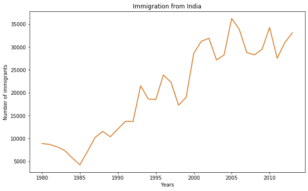

```python
years = list(map(str,range(1980,2014)))
india_imgt = canada.loc['India', years]
india_imgt.plot(figsize=(10,6));
india_imgt.plot(kind='line');
plt.title('Immigration from India');
plt.ylabel('Number of immigrants');
plt.xlabel('Years');
```

#### Plotting two countries and comparing

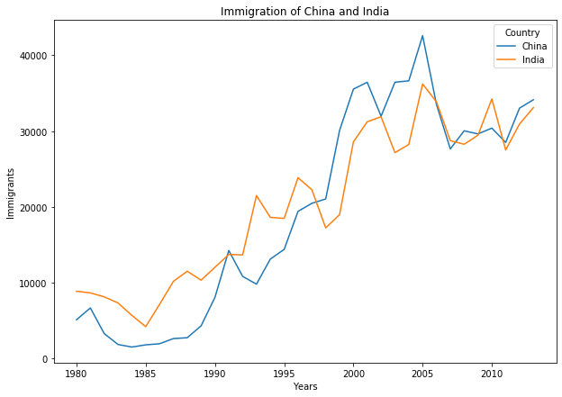

```python
canada.loc[['China','India'], years].transpose().plot(figsize =(10,7));
plt.title('Immigration of China and India');
plt.xlabel('Years');
plt.ylabel('Immigrants');
```

### Area Plots

#### Unstacked

[figure not shown]

```python
top5_clean = canada.head(5)[years].transpose()
top5_clean.index
top5_clean.index = top5_clean.index.map(int)
top5_clean.plot(kind="area", stacked=False, figsize=(20,10), alpha=0.25)
plt.title('Immigration trends in top five countries (1980-2013)')
plt.xlabel('Years')
plt.ylabel('Immigrants count')
plt.show()
```

#### Stacked

[figure not shown]

```python
top5_clean.plot(kind="area", stacked=True, figsize=(20,10), alpha=0.25)
plt.title('Immigration trends in top five countries (1980-2013)')
plt.xlabel('Years')
plt.ylabel('Immigrants count')
plt.show()
```

### Bar PLots and Histograms

```python
df_can = canada
```

### Bar

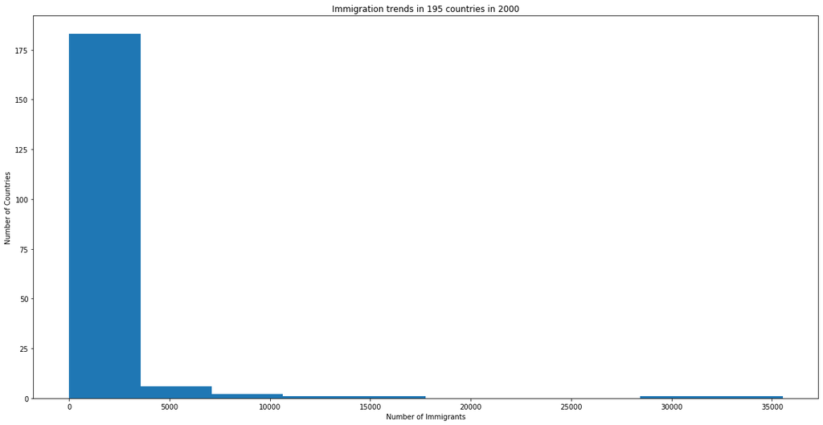

```python
df_can['2000'].plot(kind='hist', figsize=(20,10))
plt.title('Immigration trends in 195 countries in 2000')
plt.xlabel('Number of Immigrants')
plt.ylabel('Number of Countries')
plt.show()
```

### Histogram

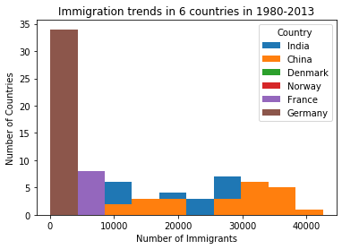

```python
df_can.loc[['India','China','Denmark','Norway','France','Germany'], years].transpose().plot.hist()

plt.title('Immigration trends in 6 countries in 1980-2013')
plt.xlabel('Number of Immigrants')
plt.ylabel('Number of Countries')

plt.show()
```

### Vertical Bar Plots

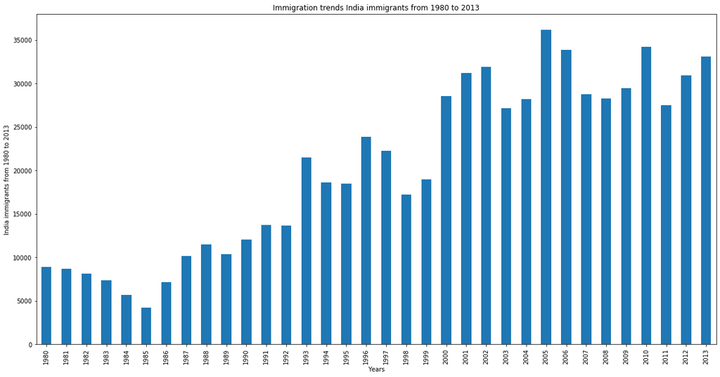

```python
india = df_can.loc['India', years]

india.plot(kind='bar', figsize=(20,10))

plt.title('Immigration trends India immigrants from 1980 to 2013')
plt.xlabel('Years')
plt.ylabel('India immigrants from 1980 to 2013')

plt.show()
```

### Horizontal Bar Plots

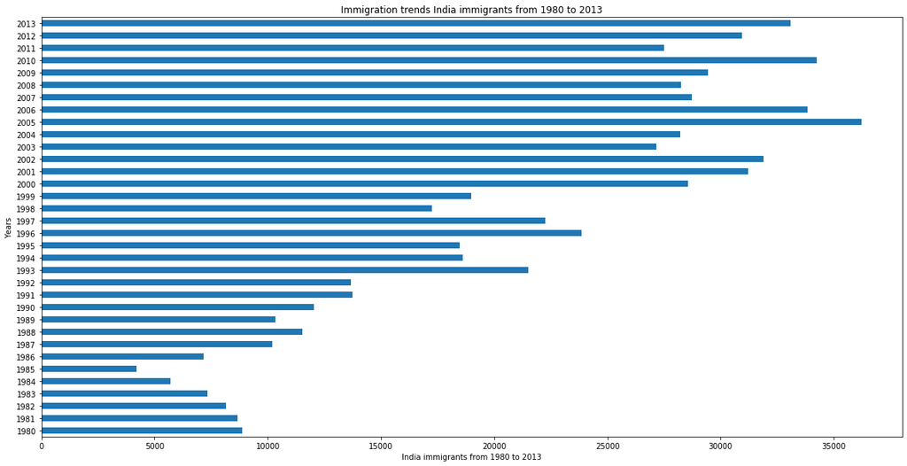

```python
india = df_can.loc['India', years]

india.plot(kind='barh', figsize=(20,10))

plt.title('Immigration trends India immigrants from 1980 to 2013')
plt.xlabel('India immigrants from 1980 to 2013')
plt.ylabel('Years')
plt.show()
```

### Using annotate

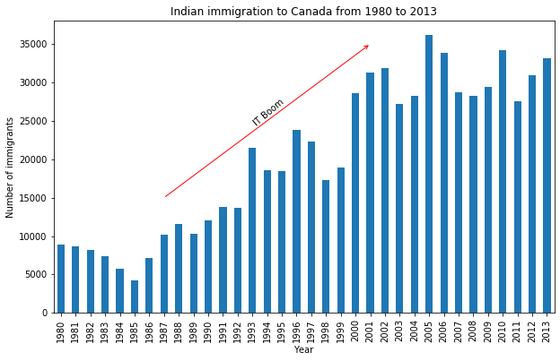

```python
df_india = df_can.loc['India',years]
df_india.plot(kind='bar', figsize=(10,6))
plt.title("Indian immigration to Canada from 1980 to 2013")
plt.xlabel("Year")
plt.ylabel("Number of immigrants")
plt.annotate('',  #arrow title
             xy=(21,35000), #x,y of arrow head
             xytext=(7,15000), #x, y of arrow tail
             xycoords='data',  #keep unchanged
             arrowprops=dict(arrowstyle='->',color='red') #arrow style with color
             )
plt.annotate('IT Boom', #add text to arrow
             xy=(13,28000),  #x, y of text position
             rotation=40, # counter clockwise rotate text by angle
             xycoords='data', #keep unchanged
             va='top', #position text
             ha='left') #position text
plt.show()
```

# Assignment

#### Which two countries have similar immigration trends over the years 1980-2013?

```python
canada['total_immigration'] = canada.sum(axis='columns')
canada.sort_values(by='total_immigration', ascending=False, axis='index', inplace=True)
canada.head(10)
```

[output not shown]

10 rows × 39 columns

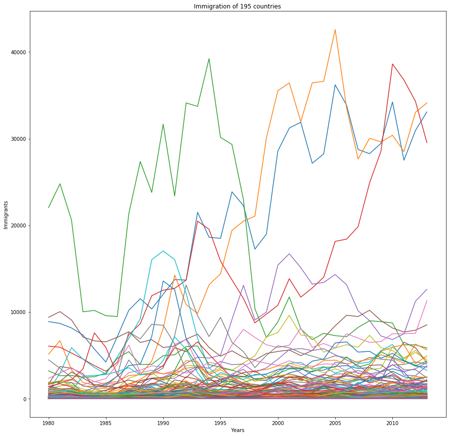

```python
canada.loc[canada.index.tolist(), years].transpose().plot(figsize=(15,15),legend=False);
plt.title('Immigration of 195 countries');
plt.xlabel('Years');
plt.ylabel('Immigrants');
```

#### Plotting three similar countries after year 2009 in the top 10 list.

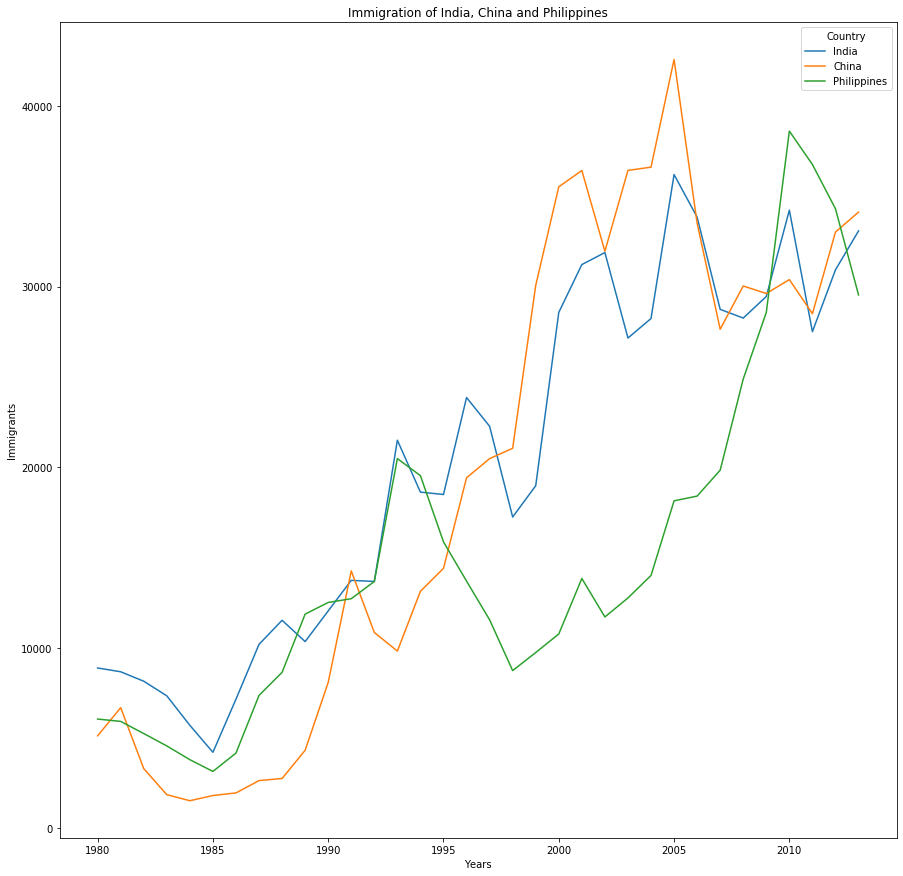

```python
canada.loc[['India','China','Philippines'], years].transpose().plot(figsize=(15,15));
plt.title('Immigration of India, China and Philippines');
plt.xlabel('Years');
plt.ylabel('Immigrants');
```

#### As it is impossible to compare 195 countries and their charts, Last 3 year's average is taken and compared in the following steps. The selection of n years is random.

### Taking avg. of last 3 years and cleaning the Series

```python
canada['avglast3'] = (canada['2011']+canada['2012']+canada['2013'])/3
l3 = canada['avglast3']
l3 = l3.sort_values(ascending = False )
l3 = l3.round()
l3 = l3[l3>2]
```

```python
l3.head(10)
```

```
Country
Philippines                                             33541.0
China                                                   31885.0
India                                                   30510.0
Pakistan                                                10433.0
Iran (Islamic Republic of)                               8768.0
United States of America                                 8023.0
United Kingdom of Great Britain and Northern Ireland     6075.0
Haiti                                                    5508.0
France                                                   5328.0
Iraq                                                     5052.0
Name: avglast3, dtype: float64
```

### Removing outliers

```python
l5 = l3[l3<11000];
```

#### Calculating Standard Deviation for bins

```python
np.std(l5)
```

```
1629.5934270734047
```

### Creating bins

```python
type(l5)
dl5 = df(l5)
dl5
ahg = pd.Series(range(0,12000,1630))
bins = ahg
dl5['binned'] = pd.cut(dl5['avglast3'], bins)
```

### Plotting the bar graph

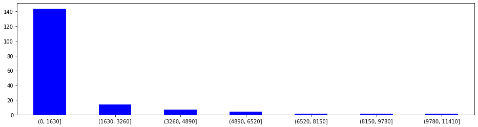

```python
out = dl5['binned']
ax = out.value_counts(sort=False).plot.bar(rot=0, color="b", figsize=(16,4))
plt.show()
```

### Bin values

```python
dl5['binned'].value_counts(sort=True)
```

```
(0, 1630]        144
(1630, 3260]      14
(3260, 4890]       7
(4890, 6520]       4
(9780, 11410]      1
(8150, 9780]       1
(6520, 8150]       1
Name: binned, dtype: int64
```

## Countries showing similar trends (2011-2013), grouped

```python
print('(9780, 11410]')
print(' {ho} {jo}'.format(ho = l5.index[0], jo = l5[0]))
print('')
print('')
print('(8150, 9780]')
print(' {ho} {jo}'.format(ho = l5.index[1], jo = l5[1]))
print('')
print('')
print('(6520, 8150]')
print(' {ho} {jo}'.format(ho = l5.index[2], jo = l5[2]))
print('')
print('')
print('(4890, 6520]')
print(' {jo}'.format(jo = l5[3:7]))
print('')
print('')
print('(3260, 4890]')
print(' {jo}'.format(jo = l5[7:14]))
print('')
print('')
print('(1630, 3260]')
print(' {jo}'.format(jo = l5[14:28]))
print('')
print('')
print('(0, 1630]')
print(' {jo}'.format(jo = l5[28:172]))
```

```
(9780, 11410]
 Pakistan 10433.0


(8150, 9780]
 Iran (Islamic Republic of) 8768.0


(6520, 8150]
 United States of America 8023.0


(4890, 6520]
 Country
United Kingdom of Great Britain and Northern Ireland    6075.0
Haiti                                                   5508.0
France                                                  5328.0
Iraq                                                    5052.0
Name: avglast3, dtype: float64


(3260, 4890]
 Country
Republic of Korea    4804.0
Egypt                4794.0
Algeria              4143.0
Mexico               4057.0
Colombia             3913.0
Morocco              3846.0
Nigeria              3573.0
Name: avglast3, dtype: float64


(1630, 3260]
 Country
Bangladesh                          3041.0
Sri Lanka                           3014.0
Ukraine                             2422.0
Lebanon                             2286.0
Afghanistan                         2281.0
```

[output cut: 11 more lines]

```

(0, 1630]
 Country
Romania              1625.0
Brazil               1621.0
Tunisia              1524.0
Eritrea              1412.0
Jordan               1365.0
                      ...
Equatorial Guinea       6.0
Mozambique              6.0
Brunei Darussalam       5.0
Cabo Verde              4.0
Tonga                   3.0
Name: avglast3, Length: 144, dtype: float64
```

## Plots

### Comparison on basis of average of immigrants between years 2011 and 2013

#### Top 3 - excluding India, China and Philippines

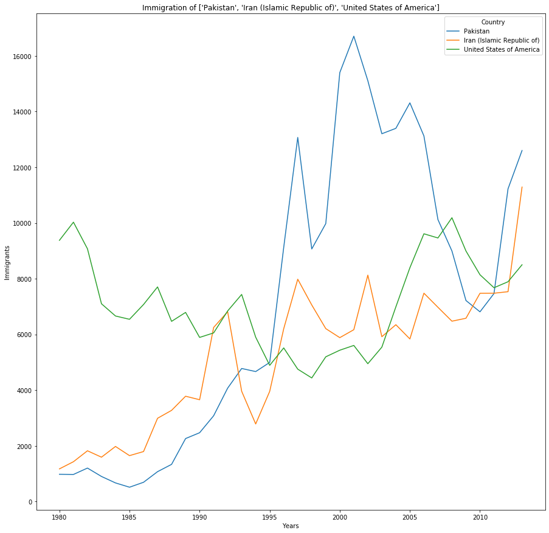

```python
a1 = l5[0:3].index.tolist()
canada.loc[a1, years].transpose().plot(figsize=(15,15));
plt.title('Immigration of {as1}'.format(as1 = a1));
plt.xlabel('Years');
plt.ylabel('Immigrants');
```

#### Inference

##### We can see that Pakistan and Iran show similar trend 2011 onwards, while on the other hand USA and Pakistan show similar trends between the years 2007 and 2011

#### Countries in Range - (3260, 6520]

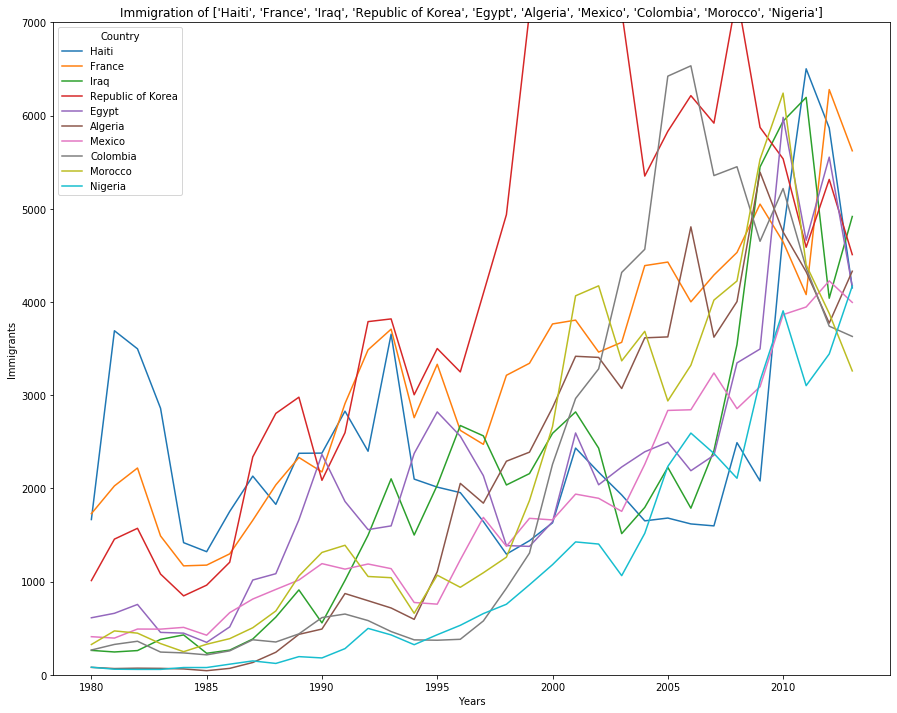

```python
years = list(map(str,range(1980,2014)))
a2 = l5[4:14].index.tolist()
canada.loc[a2, years].transpose().plot(figsize=(15,12));
plt.title('Immigration of {as2}'.format(as2 = a2));
plt.xlabel('Years');
plt.ylabel('Immigrants');
plt.ylim((0,7000));
```

#### Inference

##### We can see that all countries except South Korea show almost similar trend throughout from 1980 to 2013.

#### Countries in Range - (1630, 3260]

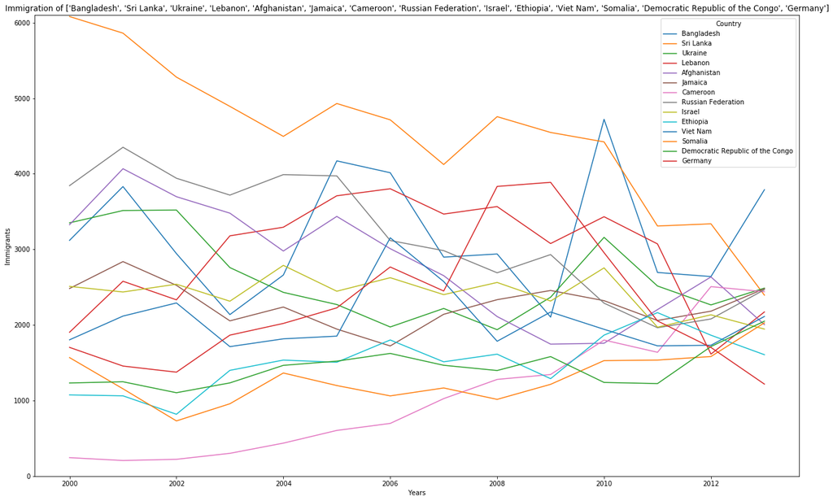

```python
years1 = list(map(str,range(2000,2014)))
a4 = l5[14:28].index.tolist()
canada.loc[a4, years1].transpose().plot(figsize=(21,13));
plt.title('Immigration of {as4}'.format(as4 = a4));
plt.xlabel('Years');
plt.ylabel('Immigrants');
plt.ylim((0,6100));
```

#### Inference

##### For ease of comparison, timeline has been reduced to 14 years. Other than Sri Lanka (highest value, 2000) and Cameroon (lowest value, 2000) show similar trends throughout from 2000 to 2013.

#### Countries in Range - (1000, 1630]

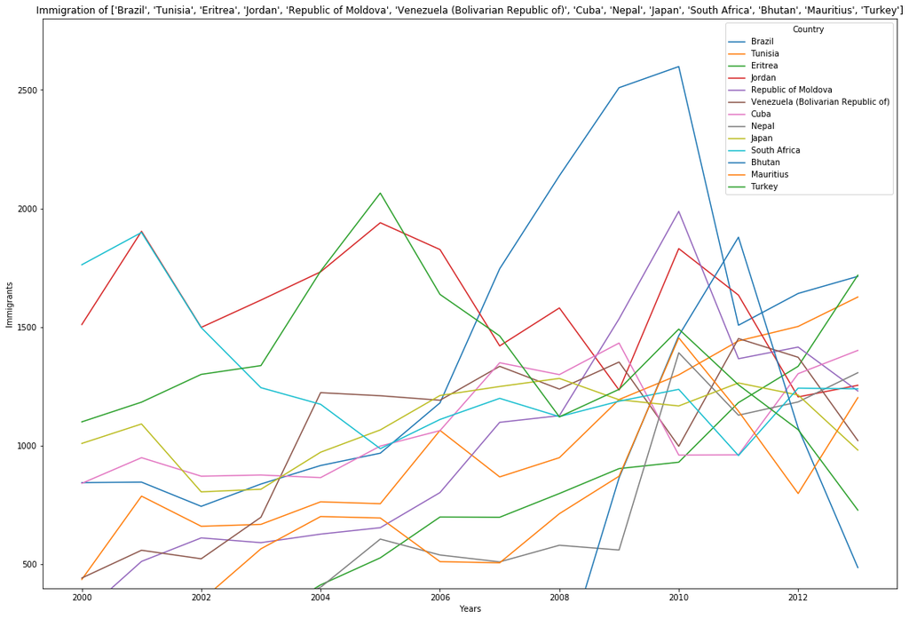

```python
a4 = l5[29:42].index.tolist()
canada.loc[a4, years1].transpose().plot(figsize=(19,13));
plt.title('Immigration of {as4}'.format(as4 = a4));
plt.xlabel('Years');
plt.ylabel('Immigrants');
plt.ylim((400,2800));
```

#### Inference

##### For ease of comparison, timeline has been reduced to 14 years. Except Brazil, which shows a sudden spike after 2006 and Bhutan, which is low throughout and values only spike in year 2011, all other countries are in the 500 - 2000 bracket with inconsistent trends.

# Key comparisons and analysis

## India

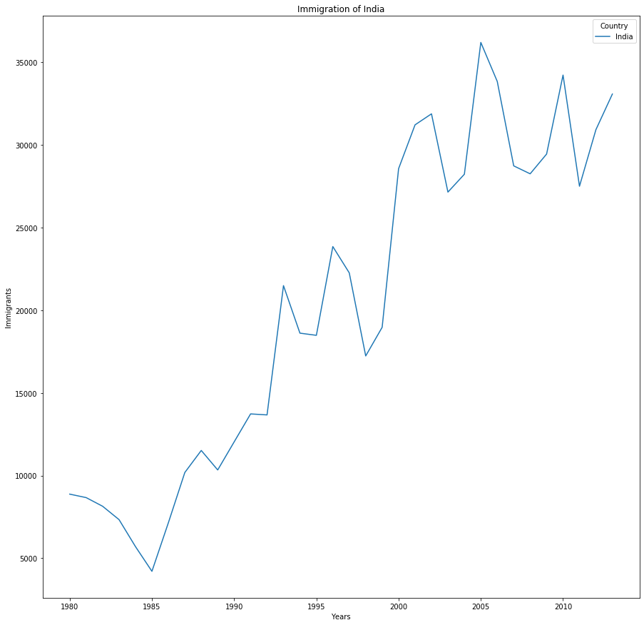

```python
canada.loc[['India'], years].transpose().plot(figsize =(15,15));
plt.title('Immigration of India');
plt.xlabel('Years');
plt.ylabel('Immigrants');
```

### Inference

#### Fist spike is observed during FY 1985-1986. Next spike is observed in 1990-1991. This can be attributed to Liberalization. Following that in 1995-1996 india became the fifth largest economy in world with 3.9% share in world GDP. We can see that 1999-2000 there is a spike. This can be attributed to the Y2k bug solution.

## India and China

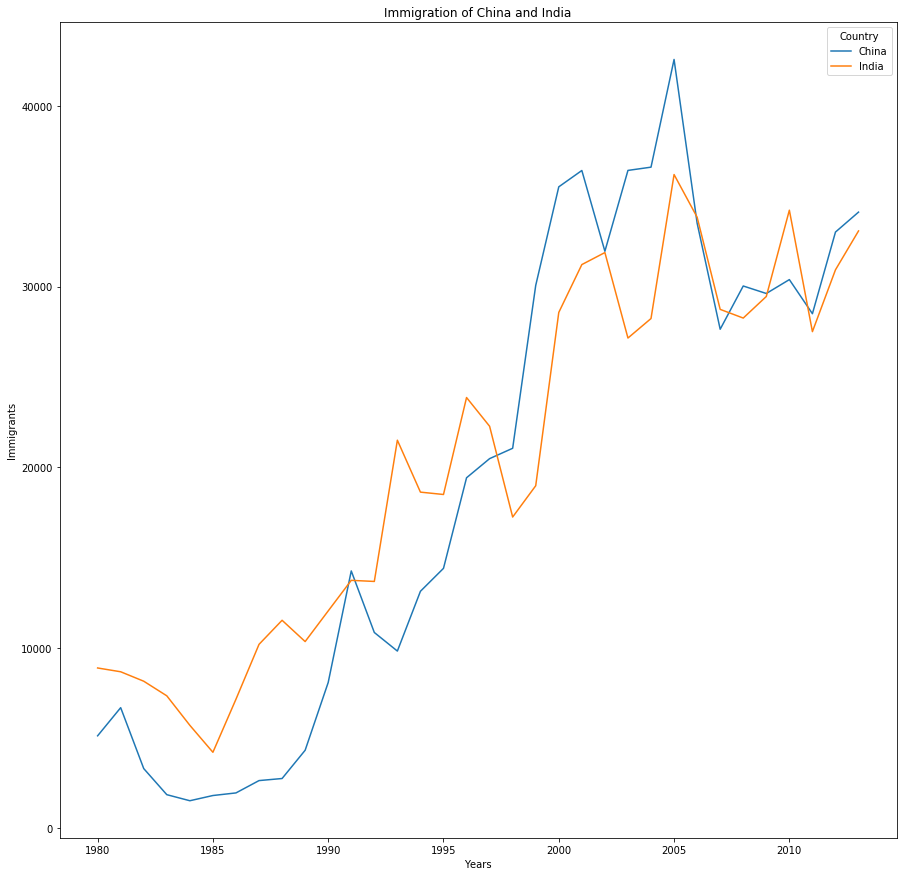

```python
canada.loc[['China','India'], years].transpose().plot(figsize =(15,15));
plt.title('Immigration of China and India');
plt.xlabel('Years');
plt.ylabel('Immigrants');
```

### Inference

#### Both countries show a steady growth rate, which starts to plateau after 2001.

### China

#### China has strengthened its export sector, which has attributed to a decline in the increasing immigration rate.

## Lebanon and Sri Lanka

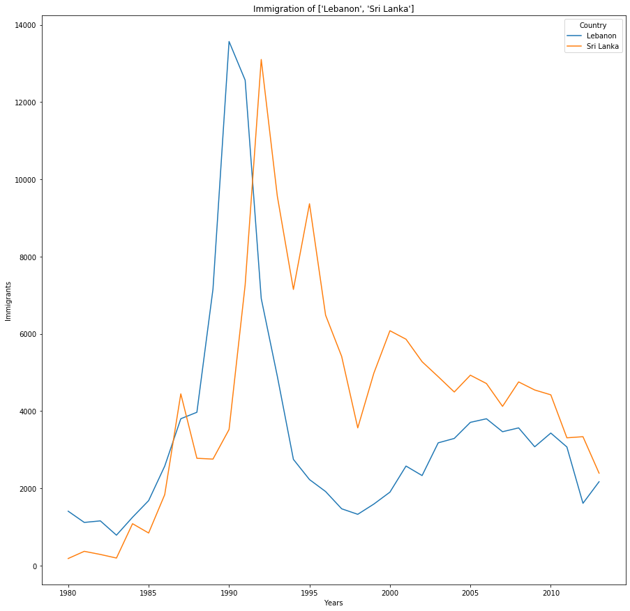

```python
a9 = ['Lebanon', 'Sri Lanka']
canada.loc[['Lebanon', 'Sri Lanka'], years].transpose().plot(figsize=(15,15));
plt.title('Immigration of {as9}'.format(as9 = a9));
plt.xlabel('Years');
plt.ylabel('Immigrants');
```

### Sri Lanka

#### Increased privatization, economic reform, and a stress on export-oriented growth helped improve the economic performance, increasing GDP growth to 7% in 1993. This attributes to the drop in immigrants from Sri Lanka.

### Lebanon

#### The Lebanese Civil war which ended in 1990, severely damaged the Lebanese economy. This dropped continously for four years until 1994, when the Real GDP rose to 8%. This was possible because of the government's 20 billion dollar reconstruction program, which managed to create new jobs, making way for immigrants to return back

## Pakistan and South Korea (Republic of Korea)

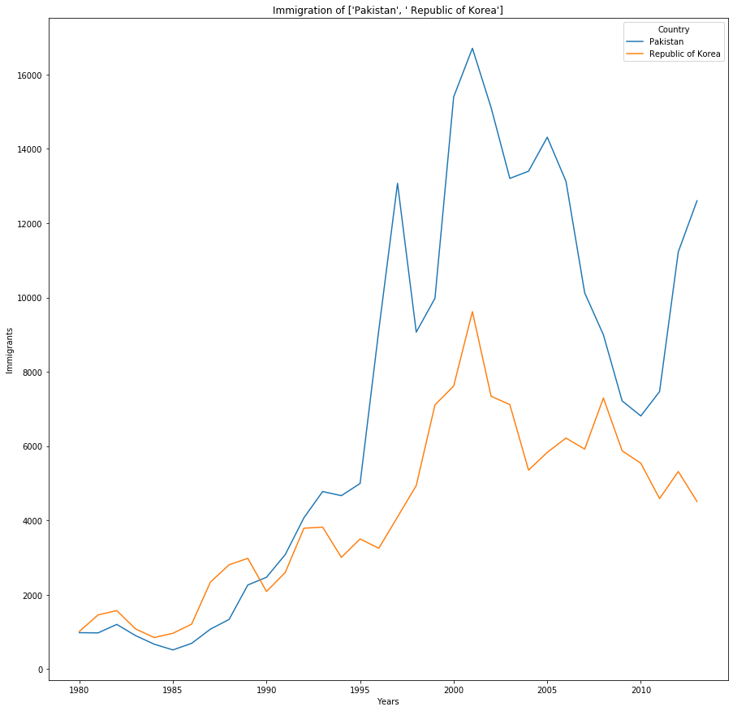

```python
a9 = ['Pakistan',' Republic of Korea']
canada.loc[['Pakistan', 'Republic of Korea'], years].transpose().plot(figsize=(15,15));
plt.title('Immigration of {as9}'.format(as9 = a9));
plt.xlabel('Years');
plt.ylabel('Immigrants');
```

### Inference

#### Both countries follow a similar trendline. The graph shows steady increase till about the year 1995. Both countries show a drop in the 2000-2002 period.

### Pakistan:

#### In 1994 inflation rate in Pakistan went to a whopping 14.5%. The following year the GDP growth rate dropped from 4.5% to 1.7%, lowest in decades. Pakistan's GDP growth rate dropped from 7.68% to 1.7% in a period of 4 years.

#### In 1999 Pervez Musharraf lead a millitary coup and overthrew the Nawaz Sharif government. This resulted in Liberalization. During Musharraf's term (1999-2008), around 11,9 million new jobs were created. Therefore this can be attributed to the drop in immigrants. Also, immigration was affected due to various events that happened in USA during 2001.

### South Korea:

#### In 2000, the Korean economy shifted to a more market oriented economy. Growth rates touched closer to 11%, highest in decades. This resulted a drop in immigrants.

## Individual trend analysis

## Romania

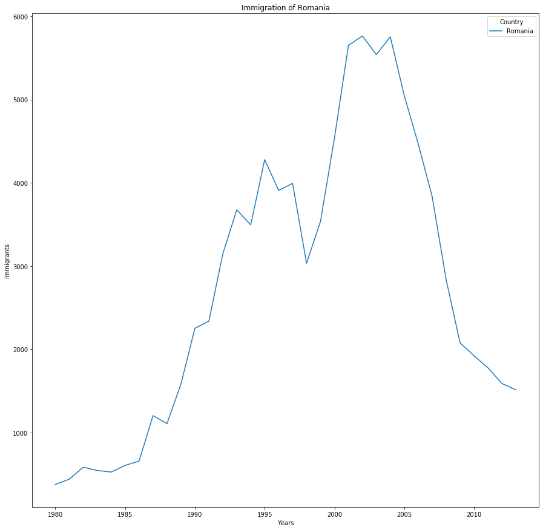

```python
years = list(map(str,range(1980,2014)))
canada.loc[['Romania'], years].transpose().plot(figsize=(15,15));
plt.title('Immigration of Romania');
plt.xlabel('Years');
plt.ylabel('Immigrants');
```

### Inference

#### Point of Interest: 2004-2006 period.

#### This was the period of FDI in Romania. Demand of Romanian products increased in EU. Also, as Romania closed in towards joining EU, immigration to other countries substantially reduced,

## Philippines

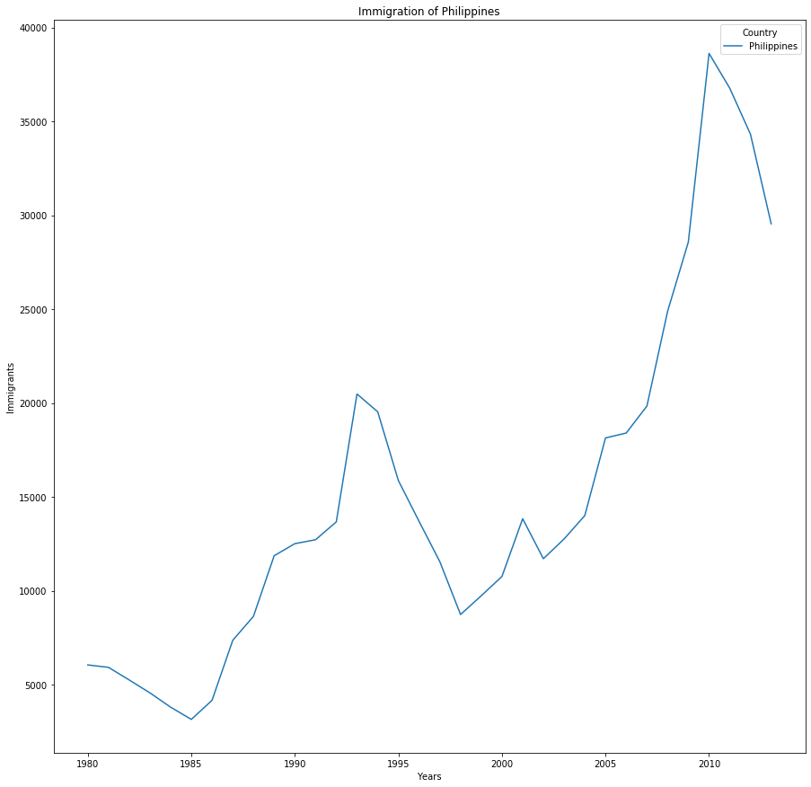

```python
years = list(map(str,range(1980,2014)))
canada.loc[['Philippines'], years].transpose().plot(figsize=(15,15));
plt.title('Immigration of Philippines');
plt.xlabel('Years');
plt.ylabel('Immigrants');
```

### Inference

#### Points of Interests: 1985 and 1998

#### In the 1980s, annual GDP growth rate dropped to 2%, which was the lowest in decades. This resulted in people immigrating for jobs. Just like South Korea, the Asian Financial Crisis affected Philippines, which explains the spike after 1998,

## United Kingdom

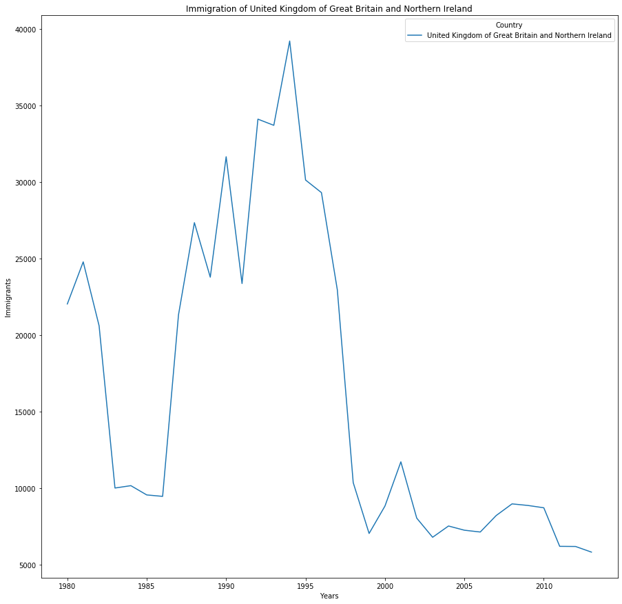

```python
years = list(map(str,range(1980,2014)))
canada.loc[['United Kingdom of Great Britain and Northern Ireland'], years].transpose().plot(figsize=(15,15));
plt.title('Immigration of United Kingdom of Great Britain and Northern Ireland');
plt.xlabel('Years');
plt.ylabel('Immigrants');
```

### Inference

#### The John Major government in 1990 fucussed to creating new jobs, which substancially rediced the unemployment rate. This resulted in tyhe immigrants returning back to the UK, which can be seen as the graph is seen dipping post 1994.

## Viet Nam

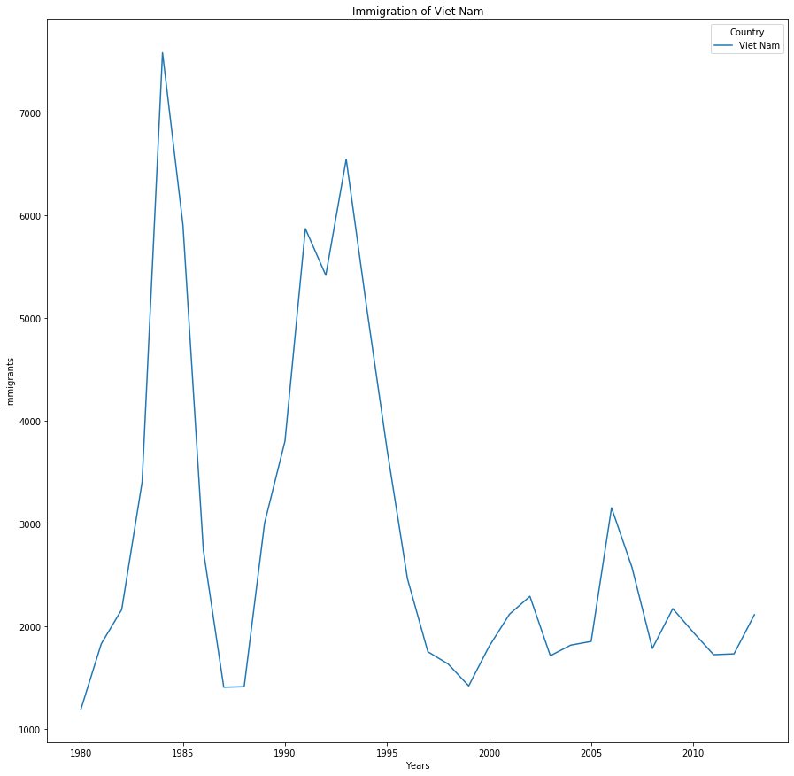

```python
years = list(map(str,range(1980,2014)))
canada.loc[['Viet Nam'], years].transpose().plot(figsize=(15,15));
plt.title('Immigration of Viet Nam');
plt.xlabel('Years');
plt.ylabel('Immigrants');
```

### Inference

#### Points of interest: 1983-1998 and 1993,

#### Vietnam entered its Third Five-Year-Plan scheme in 1981. This resulted in a massive economic failure, slowing down the economic growth heavily. The government swiftly corrected its path. Increase in exports is the main reason for immigrants to drop post 1993. This was done to bring back the economy on track.